# Linearna regresija: teža možganov pri sesalcih

## 1. Opis podatkov

```r
mozgani<-read.csv("./mozgani.csv", header=TRUE)
str(mozgani)
```

```
## 'data.frame':    59 obs. of  4 variables:
##  $ vrsta  : chr  "Aotus trivirgatus" "Aplodontia rufa " "Blarina brevicauda " "Bos taurus" ...
##  $ slovime: chr  "Ponocna opica" "Planinski bober" "Rovka" "Krava" ...
##  $ telteza: num  0.48 1.35 0.005 464.983 36.328 ...
##  $ mozteza: num  15.5 8.1 0.14 423.01 119.5 ...
```

## 2. Opisna statistika

Izračunali bomo opisno statistiko za naše podatke v obliki povzetka s petimi števili (minimum, maksimum, prvi in tretji kvartil, mediano), vzorčni povprečji in vzorčna standardna odklona telesne teže in teže možganov.

```r
summary(mozgani$telteza)
```

```
##     Min.  1st Qu.   Median     Mean  3rd Qu.     Max.
##    0.005    0.768    3.385  208.840   53.830 6654.180
```

```r
sd(mozgani$telteza)
```

```
## [1] 920.9927
```

Vidimo, da masa vzorca telesne teže sesalca varira med $0.005$ in $6654.180$kg. Povprečna telesna teža znaša $208.840$kg s standardnim odklonom $920.9927$ kg. Postopek računanja ponovimo še za vzorce teže možganov.

```r
summary(mozgani$mozteza)
```

```
##    Min. 1st Qu.  Median    Mean 3rd Qu.    Max.
##    0.14    5.60   21.00  297.41  172.00 5711.86
```

```r
sd(mozgani$mozteza)
```

```
## [1] 951.7869
```

Vidimo, da teža možganov varira med $0.14$ in $5711.86$. Povrpečna teža možganov znaša $297.41$g s standardnim odklonom $951.7869$g. Razpon vrednosti telesnih tež sesalcev in teže njihovih možganov nam pomaga pri izbiri mej na oseh razsevnega diagrama.

## 3. Razsevni diagram in vzorčni koeficient korealcije

Prikažimo dobljene podatke na razsevnem diagramu.

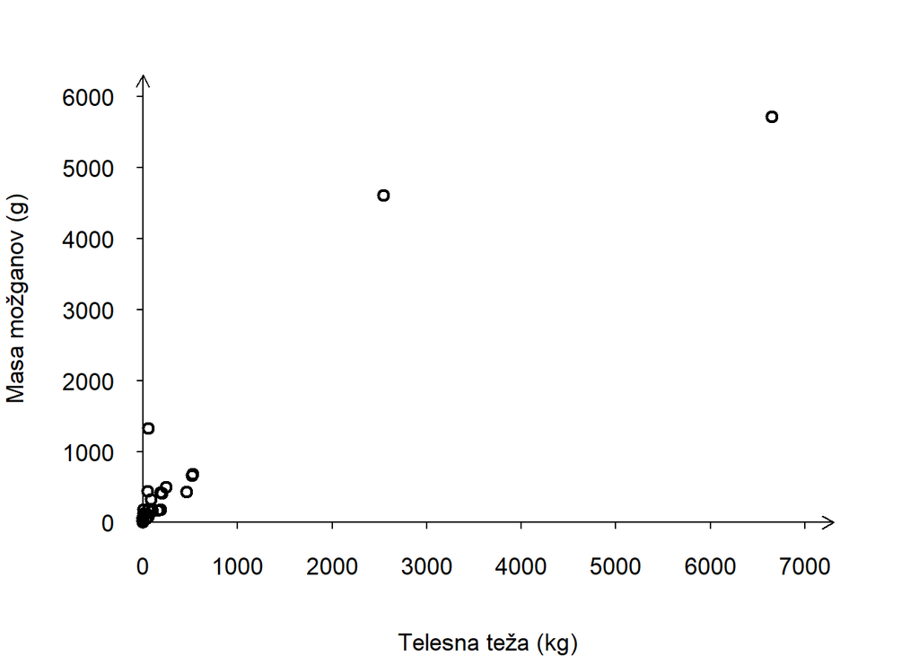

```r
par(las=1, cex=1.1, mar=c(4,4,2,2))
plot(mozgani$telteza, mozgani$mozteza, main="", xlim=c(0,7300), ylim=c(0,6300),
xlab="Telesna teža (kg)", ylab="Masa možganov (g)", lwd=2, axes=FALSE)
axis(1,pos=0,at=seq(0,7000,by=1000),tcl=-0.2)
axis(2,pos=0,at=seq(0,6000,by=1000),tcl=-0.2)
arrows(x0=7000,y0=0,x1=7300,y1=0,length=0.1)
arrows(x0=0,y0=6000,x1=0,y1=6300,length=0.1)
```

Točke na razsevnem diagramu se nahajajo okoli namišljene premice, torej lahko sklepamo, da je linearni model primeren.. Moč korelacije preverimo še z računanjem Pearsonovega koeficienta korelacije.

```r
(r<-cor(mozgani$telteza,mozgani$mozteza))
```

```
## [1] 0.9340911
```

Vrednost vzorčnega koeficienta korelacije je visoka ($r=0.9340911$), kar pomeni, da je linearna povezanost telesne teže sesalcev z težo njihovih možganov visoka. Koeficient korelacije je pozitiven, kar nam pove, da imajo vrste sesalcev, ki imajo manjšo telesno težo, tudi manjšo težo možganov.

## 4. Formiranje linearnega regresijskega modela

Formirajmo linearni regresijski model.

```r
(model<-lm(mozteza~telteza,data=mozgani))
```

```
##
## Call:
## lm(formula = mozteza ~ telteza, data = mozgani)
##
## Coefficients:
## (Intercept)      telteza
##     95.8111       0.9653
```

Dobili smo ocenjeno regresijsko premico $\hat{y}=95.8111 + 0.9653x$, oziroma oceni odseka in naklona sta enaki $\hat{a}= 95.8111$ in $\hat{b}=0.9653$.

## 5. Točke visokega vzvoda in osamelci

Identificirajmo točke visokega vzvoda in osamelce. Vrednost $x$ je točka visokega vzvoda, če je njen vzvod večji od $\frac{4}{n}$.

```r
mozgani[hatvalues(model)>4/nrow(mozgani),]
```

```
##                  vrsta      slovime telteza mozteza
## 16     Elephas maximus Azijski slon 2547.07 4603.17
## 30 Loxodonta africana  Afriski slon 6654.18 5711.86
```

Odkrili smo 2 točki visokega vzvoda. Obe vrsti sesalcev imata telesno težo nad 1000kg.

Za podatke majhne in srednje velikosti vzorca je osamelec podatkovna točka, kateri ustreza standardizirani ostanek izven intervala $[-2, 2]$.

```r
mozgani[abs(rstandard(model))>2,]
```

```
##                   vrsta      slovime  telteza mozteza
## 16      Elephas maximus Azijski slon 2547.070 4603.17
## 29 Homo sapiens sapiens       Clovek   61.998 1320.02
## 30  Loxodonta africana  Afriski slon 6654.180 5711.86
```

## 6. Preverjanje predpostavk linearnega regresijskega modela

Predpostavke linearnega regresijskega modela bomo preverili s štirimi grafi, ki se imenujejo diagnostični grafi (ali grafi za diagnostiko modela). Če neke predpostavke modela niso izpolnjene, so lahko ocene neznanih parametrov, $p$-vrednost testa, intervali zaupanja in intervali predikcije netočni.

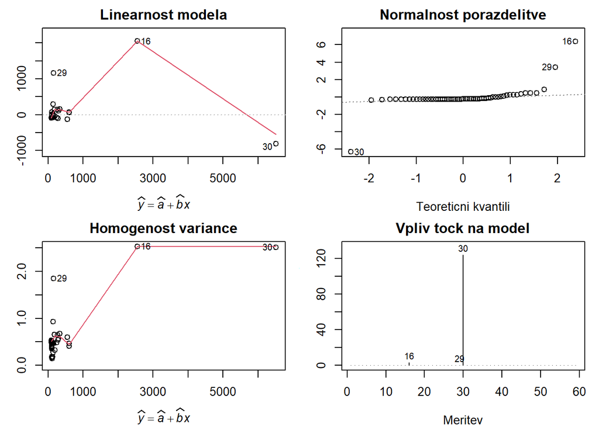

```r
par(mfrow=c(2,2),mar=c(4,3,2,1))
plot(model,which=1,caption="",ann=FALSE)
title(xlab=expression(italic(widehat(y)==widehat(a)+widehat(b)*x)),
ylab="Ostanki",main="Linearnost modela")
plot(model,which=2,caption="", ann=FALSE)
title(xlab="Teoretični kvantili", ylab= "St. ostanki",
main="Normalnost porazdelitve")
plot(model,which=3,caption="",ann=FALSE)
title(xlab=expression(italic(widehat(y)==widehat(a)+widehat(b)*x)),
ylab=expression(sqrt(paste("|St. ostanki|"))), main="Homogenost variance")
plot(model,which=4,caption="", ann=FALSE)
title(xlab="Meritev",ylab="Cookova razdalja", main="Vpliv točk na model")
```

### 1) Graf za preverjanje linearnosti modela

Validnost linearnega regresijskega modela lahko preverimo tako, da narišemo graf ostankov v odvisnosti od $x$ vrednosti ali od predvidenih vrednosti $\hat{y}$ = $\hat{a}x$ + $\hat{b}$ in preverimo, če obstaja kakšen vzorec. Če so točke dokaj enakomerno raztresene nad in pod premico $Ostanki = 0$ in ne moremo zaznati neke oblike, je linearni model validen. Če na grafu opazimo kakšen vzorec (npr. točke formirajo nelinearno funkcijo), nam sama oblika vzorca daje informacijo o funkciji od $x$, ki manjka v modelu.

### 2) Graf normalnosti porazdelitve naključnih napak

Normalnost porazdelitve naključnih napak preverjamo s pomočjo grafa porazdelitve standardiziranih ostankov. Na $x$-osi Q - Q grafa normalne porazdelitve so podani teoretični kvantili, na $y$ - osi pa kvantili standardiziranih ostankov. Če dobljene točke na Q-Q grafu tvorijo premico (z manjšimi odstopanji), zaključimo, da je porazdelitev naključnih napak (vsaj približno) normalna.

Za podatke o telesni teži sesalcev in njihovih možganov lahko sklenemo, da so naključne napake normalno porazdeljene (ni večjih odstopanj od premice, razen za 16., 29., in 30. podatkovno točko).

### 3) Graf homogenosti variance

Učinkovit graf za registriranje nekonstantne variance je graf korena standardiziranih ostankov v odvisnosti od $x$ ali od predvidenih vrednosti $\hat{y} = \hat{a}x + \hat{b}$. Če variabilnost korena standardiziranih ostankov narašča ali pada s povečanjem vrednosti $\hat{y}$, je to znak, da varianca naključnih napak ni konstantna. Pri naraščanju variance je graf pogosto oblike $\triangleleft$, in pri padanju variance oblike $\triangleright$. Pri ocenjevanju lahko pomaga funkcija glajenja, v primeru konstantne variance se pričakuje horizontalna črta, okoli katere so točke enakomerno razporejene.

Iz točk na grafu lahko sklepamo, da ni pretiranega padanja variance, naraste pa le za 16. in 30. podatkovno točko. Ničelna domneva konstantne variance se lahko formalno preveri s Breusch-Paganovim testom. ¸¸

```r
suppressWarnings(library(car))
ncvTest(model)
```

```
## Non-constant Variance Score Test
## Variance formula: ~ fitted.values
## Chisquare = 149.0271, Df = 1, p = < 2.22e-16
```